# Weather & Airline Delays - Fall’25 Data Wrangling Project

*(Markdowns corresponds to the code below it)*

```python
import sys
import pandas as pd
import numpy as np
import matplotlib

print("Python executable:", sys.executable)
```

```
Python executable: C:\Users\MONISH~1\ANACON~3\envs\wrangle\python.exe
```

```python
print("pandas:", pd.__version__)
```

```
pandas: 2.3.3
```

```python
print("numpy:", np.__version__)
```

```
numpy: 2.2.5
```

```python
print("matplotlib:", matplotlib.__version__)
```

```
matplotlib: 3.10.6
```

## **Data Load:**

Read the three source CSVs (NOAA storm events, airport codes, and BTS delay summaries) into pandas DataFrames

```python
import pandas as pd
storm_events   = pd.read_csv(r"C:\Users\Monisha Kohli\OneDrive - The University of Texas at Austin\Projects\Data Wrangling FA25\Project\StormEvents_details-ftp_v1.0_d2024_c20250818.csv")
airport_codes  = pd.read_csv(r"C:\Users\Monisha Kohli\OneDrive - The University of Texas at Austin\Projects\Data Wrangling FA25\Project\airport-codes.csv")
airport_delays = pd.read_csv(r"C:\Users\Monisha Kohli\OneDrive - The University of Texas at Austin\Projects\Data Wrangling FA25\Project\Airline_Delay_Cause.csv")
```

```python
#Row Counts

row_counts = {
    "storm_events": len(storm_events),
    "airport_codes": len(airport_codes),
    "airport_delays": len(airport_delays)
}

pd.DataFrame.from_dict(row_counts, orient="index", columns=["nrows"])
```

```
                nrows
storm_events    69493
airport_codes   82808
airport_delays  22609
```

```python
#Sample Rows

storm_events.head(3)
```

```
   BEGIN_YEARMONTH  ...  DATA_SOURCE
0           202404  ...          CSV
1           202407  ...          CSV
2           202411  ...          CSV

[3 rows x 51 columns]
```

```python
airport_codes.head(3)
```

```
  ident           type  ... local_code             coordinates
0   00A       heliport  ...        00A   40.070985, -74.933689
1  00AA  small_airport  ...       00AA  38.704022, -101.473911
2  00AK  small_airport  ...       00AK  59.947733, -151.692524

[3 rows x 13 columns]
```

```python
airport_delays.head(3)
```

```
   year  month carrier  ... nas_delay security_delay late_aircraft_delay
0  2024     12      MQ  ...      19.0            0.0               576.0
1  2024     12      MQ  ...    1251.0            0.0               454.0
2  2024     12      MQ  ...     468.0            0.0               933.0

[3 rows x 21 columns]
```

```python
# Define columns representing different delay causes
cause_cols = ["carrier_ct", "weather_ct", "nas_ct", "security_ct", "late_aircraft_ct"]

# Replace missing values in cause columns and arrival flights
airport_delays[cause_cols] = airport_delays[cause_cols].fillna(0)
airport_delays["arr_flights"] = airport_delays["arr_flights"].fillna(0)

# Calculate the total delay causes per row
airport_delays["total_causes"] = airport_delays[cause_cols].sum(axis=1)
```

```python
cause_sums = airport_delays[cause_cols].sum()
print(cause_sums)
```

```
carrier_ct          485820.12
weather_ct           57622.19
nas_ct              416812.37
security_ct           3981.78
late_aircraft_ct    566841.89
dtype: float64
```

```python
cancel_stats = {
    "sum_cancelled": airport_delays["arr_cancelled"].sum(),
    "sum_diverted": airport_delays["arr_diverted"].sum(),
    "avg_cancelled": airport_delays["arr_cancelled"].mean()
}

pd.DataFrame([cancel_stats])
```

```
   sum_cancelled  sum_diverted  avg_cancelled
0       102908.0       18831.0       4.554862
```

## **Data Cleaning:**

**Airport Codes Data Cleaning & Standardization**

This chunk cleans and standardizes the airport codes dataset. It filters to US airports, constructs a consistent `airport_code` by prioritizing IATA codes and adjusting ICAO codes where needed, and extracts state and coordinate fields. It then parses latitude/longitude into numeric columns and selects/renames relevant fields to produce a clean `airport_codes_clean` table for downstream merging and analysis.

```python
import numpy as np

ac = airport_codes.copy()

# 1) filter to US + desired airports types
ac = ac[ac['iso_country'] == 'US']
ac = ac[ac['type'].isin(['large_airport', 'medium_airport', 'small_airport'])].copy()

# 2) airport_code logic: prefer iata_code when present, else strip leading K from ident for US icao codes
# handle missing safely
ac['iata_code'] = ac.get('iata_code')  # ensures column exists or creates None series
ac['ident'] = ac.get('ident').astype(str)

# start with iata where available
ac['airport_code'] = np.where(
    ac['iata_code'].notna() & (ac['iata_code'].astype(str) != ''),
    ac['iata_code'].astype(str),
    ac['ident']
)

# if still an ident that starts with 'K' and iso_country is US, strip the leading K
mask_strip_k = (ac['airport_code'].notna()) & ac['airport_code'].astype(str).str.startswith('K')
ac.loc[mask_strip_k, 'airport_code'] = ac.loc[mask_strip_k, 'airport_code'].astype(str).str[1:]

# 3) state: last two chars of iso_region (e.g., 'US-PA' -> 'PA')
ac['iso_region'] = ac.get('iso_region').astype(str)
ac['state'] = ac['iso_region'].str[-2:]

# 4) parse coordinates: "lat, long" -> lat, lon (as floats)
coords = ac.get('coordinates').astype(str).str.split(',', n=1, expand=True)
ac['lat'] = coords[0].str.strip().replace('', np.nan).astype(float)
ac['lon'] = coords[1].str.strip().replace('', np.nan).astype(float)

# 5) Renaming columns to maintain consistency
airport_codes_clean = ac.loc[:, [
    'airport_code',
    'name',
    'iso_country',
    'state',
    'municipality',
    'type',
    'elevation_ft',
    'lat',
    'lon'
]].rename(columns={
    'name': 'airport_name',
    'municipality': 'city',
    'elevation_ft': 'elev_ft'
}).reset_index(drop=True)

#  check
print("airport_codes_clean rows:", len(airport_codes_clean))
```

```
airport_codes_clean rows: 16121
```

```python
airport_codes_clean.head(5)
```

```
  airport_code          airport_name  ...        lat         lon
0         00AA  Aero B Ranch Airport  ...  38.704022 -101.473911
1         00AK          Lowell Field  ...  59.947733 -151.692524
2         00AL          Epps Airpark  ...  34.864799  -86.770302
3         00AN  Katmai Lodge Airport  ...  59.093287 -156.456699
4         00AS        Fulton Airport  ...  34.942803  -97.818019

[5 rows x 9 columns]
```

**Airport Delays Data Cleaning & Feature Standardization**

This chunk filters the raw delay data to keep only valid months and airports with non-zero flights. It then standardizes column names, casts year/month to integers, and fills missing delay metrics with zeros for consistency. Finally, it assembles a clean, structured `airport_delays_clean` table with only the fields needed for analysis and reporting.

```python
# Start from the raw airport_delays DataFrame
ad = airport_delays.copy()

# 1) FILTER rows
ad = ad[
    ad['year'].notna() &
    ad['month'].between(1, 12) &
    ad['arr_flights'].notna() &
    (ad['arr_flights'] > 0)
].copy()

# 2) RENAME + CAST + CLEAN missing values
airport_delays_clean = ad.assign(
    yr = ad['year'].astype(int),
    mth = ad['month'].astype(int),
    airport_code = ad['airport'],

    flights = ad['arr_flights'],
    delayed_flights = ad['arr_del15'].fillna(0),
    delay_mins = ad['arr_delay'].fillna(0),

    weather_ct = ad['weather_ct'].fillna(0),
    weather_delay_mins = ad['weather_delay'].fillna(0),

    carrier_ct = ad['carrier_ct'].fillna(0),
    carrier_delay_mins = ad['carrier_delay'].fillna(0),

    cancelled = ad['arr_cancelled'].fillna(0),
    diverted = ad['arr_diverted'].fillna(0)
)[[
    "yr","mth","airport_code","flights",
    "delayed_flights","delay_mins",
    "weather_ct","weather_delay_mins",
    "carrier_ct","carrier_delay_mins",
    "cancelled","diverted"
]].reset_index(drop=True)

# preview
print("airport_delays_clean rows:", len(airport_delays_clean))
```

```
airport_delays_clean rows: 22593
```

```python
airport_delays_clean.head(5)
```

```
     yr  mth airport_code  ...  carrier_delay_mins  cancelled  diverted
0  2024   12          EVV  ...                47.0        0.0       0.0
1  2024   12          EWR  ...               335.0        0.0       0.0
2  2024   12          EYW  ...               143.0        5.0       3.0
3  2024   12          FAR  ...               245.0        2.0       0.0
4  2024   12          FSD  ...                86.0        1.0       0.0

[5 rows x 12 columns]
```

**Storm Events Data Cleaning & Year/Month Extraction**

This chunk filters raw storm records to valid states and a sensible `BEGIN_YEARMONTH` range, removing malformed or out-of-scope rows. It derives `yr` and `mth` from the `BEGIN_YEARMONTH` integer for easy temporal grouping. Finally, it selects and renames the important event, location, casualty, and damage fields to produce `storm_events_clean` ready for aggregation or spatial joins.

```python
# Start from raw storm_events DataFrame
se = storm_events.copy()

# 1) FILTER
se = se[
    se['STATE'].notna() &
    se['BEGIN_YEARMONTH'].notna() &
    (se['BEGIN_YEARMONTH'].between(200001, 203012))
].copy()

# 2) CREATE yr & mth from BEGIN_YEARMONTH
se['yr'] = (se['BEGIN_YEARMONTH'] // 100).astype(int)
se['mth'] = (se['BEGIN_YEARMONTH'] % 100).astype(int)

# 3) RENAME + SELECT
storm_events_clean = se[[
    "EVENT_ID",
    "EPISODE_ID",
    "STATE",
    "STATE_FIPS",
    "yr",
    "mth",
    "EVENT_TYPE",
    "CZ_TYPE",
    "CZ_NAME",
    "BEGIN_LAT",
    "BEGIN_LON",
    "INJURIES_DIRECT",
    "DEATHS_DIRECT",
    "DAMAGE_PROPERTY"
]].rename(columns={
    "BEGIN_LAT": "lat",
    "BEGIN_LON": "lon"
}).reset_index(drop=True)

# preview
print("storm_events_clean rows:", len(storm_events_clean))
```

```
storm_events_clean rows: 69493
```

```python
storm_events_clean.head(5)
```

```
   EVENT_ID  EPISODE_ID  ... DEATHS_DIRECT  DAMAGE_PROPERTY
0   1174463      189851  ...             0              NaN
1   1195301      193486  ...             0            0.00K
2   1223377      197838  ...             0            0.00K
3   1184135      191723  ...             0            0.00K
4   1184133      191723  ...             0            0.00K

[5 rows x 14 columns]
```

**Monthly Delay Aggregation & Percentage Metrics**

This chunk aggregates flight and delay data by year and month, computing total flights, delayed flights, and average delay minutes across all airports. It then derives percentages—overall percent delayed and percent of delay minutes due to weather—using safe division to avoid invalid values. Finally, it rounds key metrics, orders the columns consistently, and returns a clean `monthly_totals` table sorted chronologically.

```python
# monthly_totals: monthly totals across all airports (yr, mth)
import numpy as np

monthly_totals = (
    airport_delays_clean
    .groupby(['yr','mth'], as_index=False)
    .agg(
        total_flights = ('flights','sum'),
        total_delayed = ('delayed_flights','sum'),
        avg_delay_mins = ('delay_mins','mean'),
        sum_weather_delay_mins = ('weather_delay_mins','sum'),
        sum_delay_mins = ('delay_mins','sum')
    )
)

# pct_delayed: (sum delayed / sum flights) *100, with safe divide
monthly_totals['pct_delayed'] = np.round(
    np.where(monthly_totals['total_flights'] == 0, np.nan,
             monthly_totals['total_delayed'] * 100.0 / monthly_totals['total_flights']),
    2
)

# pct_weather_delay: (sum weather_delay_mins *100 / sum delay_mins), safe divide
monthly_totals['pct_weather_delay'] = np.round(
    np.where(monthly_totals['sum_delay_mins'] == 0, np.nan,
             monthly_totals['sum_weather_delay_mins'] * 100.0 / monthly_totals['sum_delay_mins']),
    2
)

# tidy - keep columns in same order to maintain consistency and round avg_delay_mins
monthly_totals['avg_delay_mins'] = monthly_totals['avg_delay_mins'].round(2)
monthly_totals = monthly_totals[['yr','mth','total_flights','total_delayed','pct_delayed','avg_delay_mins','pct_weather_delay']].sort_values(['yr','mth']).reset_index(drop=True)

monthly_totals.head()
```

```
     yr  mth  total_flights  ...  pct_delayed  avg_delay_mins  pct_weather_delay
0  2024    1       582425.0  ...        23.11         5467.55              10.43
1  2024    2       552691.0  ...        15.57         3002.54               5.44
2  2024    3       628786.0  ...        20.24         4784.14               4.31
3  2024    4       619920.0  ...        18.68         4313.52               5.22
4  2024    5       649428.0  ...        25.64         6762.21               7.44

[5 rows x 7 columns]
```

**Top 10 Airports by Flight Volume**

This chunk groups delay data by airport and computes total flights, total delayed flights, and each airport’s percent delayed using safe division. It then ranks airports by total flight volume and extracts the top 10 busiest locations. The result is a focused summary of high-traffic airports with their corresponding delay characteristics.

```python
# top10_airports: Top 10 airports by total flights
top10_airports = (
    airport_delays_clean
    .groupby('airport_code', as_index=False)
    .agg(
        total_flights = ('flights','sum'),
        total_delayed = ('delayed_flights','sum')
    )
)

top10_airports['pct_delayed'] = np.round(
    np.where(top10_airports['total_flights'] == 0, np.nan,
             top10_airports['total_delayed'] * 100.0 / top10_airports['total_flights']),
    2
)

top10_airports = top10_airports.sort_values('total_flights', ascending=False).head(10).reset_index(drop=True)
top10_airports
```

```
  airport_code  total_flights  total_delayed  pct_delayed
0          ATL       342538.0        58817.0        17.17
1          ORD       318122.0        65018.0        20.44
2          DFW       315680.0        74664.0        23.65
3          DEN       313280.0        57607.0        18.39
4          CLT       252408.0        53683.0        21.27
5          LAX       196159.0        37409.0        19.07
6          PHX       195141.0        36587.0        18.75
7          LAS       190775.0        42105.0        22.07
8          SEA       184912.0        35033.0        18.95
9          IAH       168019.0        31870.0        18.97
```

**Airports Ranked by Average Delay Duration**

This chunk calculates each airport’s average total delay minutes and average weather-related delay minutes. It rounds the metrics for readability and then identifies the top 10 airports with the highest average delays. The output highlights airports where delay duration—not just frequency—is most severe.

```python
# avg_delay_by_airport: Average delay minutes by airport (overall)
avg_delay_by_airport = (
    airport_delays_clean
    .groupby('airport_code', as_index=False)
    .agg(
        avg_delay_mins = ('delay_mins','mean'),
        avg_weather_delay_mins = ('weather_delay_mins','mean')
    )
)

avg_delay_by_airport['avg_delay_mins'] = avg_delay_by_airport['avg_delay_mins'].round(2)
avg_delay_by_airport['avg_weather_delay_mins'] = avg_delay_by_airport['avg_weather_delay_mins'].round(2)

avg_delay_by_airport = avg_delay_by_airport.sort_values('avg_delay_mins', ascending=False).head(10).reset_index(drop=True)
avg_delay_by_airport
```

```
  airport_code  avg_delay_mins  avg_weather_delay_mins
0          DFW        46439.13                 4179.42
1          DEN        32941.83                 1847.10
2          ORD        30556.89                 2107.54
3          CLT        27147.94                 1525.04
4          MCO        26992.91                  875.50
5          ATL        26698.09                 1429.05
6          DAL        24311.11                  844.81
7          SFO        21573.14                  913.91
8          JFK        20785.31                  917.54
9          SFB        19891.08                 1442.50
```

**Monthly Average Delay Per Flight (by Airport)**

This chunk computes each flight’s delay intensity by creating a `delay_per_flight` metric with safe division. It then averages this value by airport, year, and month to capture how severe delays are on a per-flight basis. The final table is rounded, chronologically ordered, and ready for trend analysis across airports.

```python
# monthly_avg_delay_per_flight: monthly average delay per flight by airport
# compute delay_per_flight per row safely, then average across rows for each airport/yr/mth
df = airport_delays_clean.copy()
df['delay_per_flight'] = np.where(df['flights'] == 0, np.nan, df['delay_mins'] / df['flights'])

monthly_avg_delay_per_flight = (
    df
    .groupby(['airport_code','yr','mth'], as_index=False)
    .agg(avg_delay_per_flight = ('delay_per_flight','mean'))
)

monthly_avg_delay_per_flight['avg_delay_per_flight'] = monthly_avg_delay_per_flight['avg_delay_per_flight'].round(2)
monthly_avg_delay_per_flight = monthly_avg_delay_per_flight.sort_values(['airport_code','yr','mth']).reset_index(drop=True)
monthly_avg_delay_per_flight.head()
```

```
  airport_code    yr  mth  avg_delay_per_flight
0          ABE  2024    1                 16.30
1          ABE  2024    2                 12.33
2          ABE  2024    3                  9.69
3          ABE  2024    4                 15.70
4          ABE  2024    5                 30.94
```

**Carrier-Level Monthly Delay Metrics**

This chunk aggregates all carrier-related delays by year and month, summing both delay counts and delay minutes. It then computes the average carrier delay duration using safe division to avoid invalid values. The final output is a clean, chronologically ordered table summarizing how carrier-originated delays evolve over time.

```python
# carrier_level_delays: carrier-level delays by yr,mth
carrier_level_delays = (
    airport_delays_clean
    .groupby(['yr','mth'], as_index=False)
    .agg(
        total_carrier_delays = ('carrier_ct','sum'),
        total_carrier_delay_mins = ('carrier_delay_mins','sum')
    )
)

carrier_level_delays['avg_carrier_delay_mins'] = np.round(
    np.where(carrier_level_delays['total_carrier_delays'] == 0, np.nan,
             carrier_level_delays['total_carrier_delay_mins'] / carrier_level_delays['total_carrier_delays']),
    2
)

carrier_level_delays = carrier_level_delays[['yr','mth','total_carrier_delays','avg_carrier_delay_mins']].sort_values(['yr','mth']).reset_index(drop=True)
carrier_level_delays.head()
```

```
     yr  mth  total_carrier_delays  avg_carrier_delay_mins
0  2024    1              40802.09                   81.28
1  2024    2              27851.65                   71.21
2  2024    3              37666.59                   76.12
3  2024    4              36045.21                   74.12
4  2024    5              47615.11                   79.77
```

**State-Level Aggregation of Airport Delays**

This chunk merges cleaned airport delays with airport codes to attach `state` to each record, ensuring keys share the same string format. It fills numeric `NaN`s with zero, then aggregates delays and counts to the state × year × month level. Finally, it computes safe derived metrics (percent delayed and average delay per flight) and returns a chronologically ordered `airport_delay_summary` table ready for mapping or state-level analysis.

```python
# join airport delays -> airport codes to get state
ad = airport_delays_clean.copy()
ac = airport_codes_clean.copy()

# ensure join key has same dtype/format
ad['airport_code'] = ad['airport_code'].astype(str)
ac['airport_code'] = ac['airport_code'].astype(str)

joined = ad.merge(ac[['airport_code','state']], on='airport_code', how='inner')

# ensure numeric cols have no nans that would break sums
num_cols = ['flights','delayed_flights','delay_mins','weather_ct','weather_delay_mins','carrier_ct','carrier_delay_mins']
for c in num_cols:
    if c in joined.columns:
        joined[c] = joined[c].fillna(0)

# aggregate to state, month, year
agg = joined.groupby(['yr','mth','state'], as_index=False).agg(
    total_flights = ('flights','sum'),
    total_delayed = ('delayed_flights','sum'),
    total_delay_mins = ('delay_mins','sum'),
    weather_ct = ('weather_ct','sum'),
    weather_delay_mins = ('weather_delay_mins','sum'),
    carrier_ct = ('carrier_ct','sum'),
    carrier_delay_mins = ('carrier_delay_mins','sum')
)

# derived metrics (safe divide)
agg['pct_delayed'] = np.round(
    np.where(agg['total_flights'] == 0, np.nan, agg['total_delayed'] * 100.0 / agg['total_flights']),
    2
)

agg['avg_delay_per_flight'] = np.round(
    np.where(agg['total_flights'] == 0, np.nan, agg['total_delay_mins'] / agg['total_flights']),
    2
)

# final ordering of columns:
airport_delay_summary = agg[[
    'yr','mth','state','total_flights','total_delayed','pct_delayed',
    'total_delay_mins','avg_delay_per_flight','weather_ct','weather_delay_mins',
    'carrier_ct','carrier_delay_mins'
]].sort_values(['yr','mth','state']).reset_index(drop=True)

#  check
print("rows in airport_delay_summary:", len(airport_delay_summary))
```

```
rows in airport_delay_summary: 600
```

```python
airport_delay_summary.head(10)
```

```
     yr  mth state  ...  weather_delay_mins  carrier_ct  carrier_delay_mins
0  2024    1    AK  ...              3225.0      200.76             14856.0
1  2024    1    AL  ...              5693.0      228.31             18788.0
2  2024    1    AR  ...              4097.0      176.96             12095.0
3  2024    1    AZ  ...             30010.0     1254.81            113225.0
4  2024    1    CA  ...             56106.0     3856.87            250653.0
5  2024    1    CO  ...             41423.0     1759.21            142066.0
6  2024    1    CT  ...              2914.0      160.86             11669.0
7  2024    1    DC  ...             20234.0      665.83             64178.0
8  2024    1    FL  ...             77913.0     4204.28            323456.0
9  2024    1    GA  ...             54108.0     1767.70            179056.0

[10 rows x 12 columns]
```

#### State name normalization (NOAA → 2-letter codes)

The NOAA storm dataset reports states using long names, many of which include non-state regions (e.g., marine zones, offshore waters). To ensure consistent joins with flight delay data—which uses 2-letter state codes—we build a canonical `state_map` lookup table. This table standardizes valid state and territory names to their corresponding 2-letter codes and filters out non-state regions during later joins.

```python
state_map = pd.DataFrame([
    ("ALABAMA","AL"), ("ALASKA","AK"), ("ARIZONA","AZ"), ("ARKANSAS","AR"),
    ("CALIFORNIA","CA"), ("COLORADO","CO"), ("CONNECTICUT","CT"), ("DELAWARE","DE"),
    ("FLORIDA","FL"), ("GEORGIA","GA"), ("HAWAII","HI"), ("IDAHO","ID"),
    ("ILLINOIS","IL"), ("INDIANA","IN"), ("IOWA","IA"), ("KANSAS","KS"),
    ("KENTUCKY","KY"), ("LOUISIANA","LA"), ("MAINE","ME"), ("MARYLAND","MD"),
    ("MASSACHUSETTS","MA"), ("MICHIGAN","MI"), ("MINNESOTA","MN"), ("MISSISSIPPI","MS"),
    ("MISSOURI","MO"), ("MONTANA","MT"), ("NEBRASKA","NE"), ("NEVADA","NV"),
    ("NEW HAMPSHIRE","NH"), ("NEW JERSEY","NJ"), ("NEW MEXICO","NM"), ("NEW YORK","NY"),
    ("NORTH CAROLINA","NC"), ("NORTH DAKOTA","ND"), ("OHIO","OH"), ("OKLAHOMA","OK"),
    ("OREGON","OR"), ("PENNSYLVANIA","PA"), ("RHODE ISLAND","RI"),
    ("SOUTH CAROLINA","SC"), ("SOUTH DAKOTA","SD"), ("TENNESSEE","TN"), ("TEXAS","TX"),
    ("UTAH","UT"), ("VERMONT","VT"), ("VIRGINIA","VA"), ("WASHINGTON","WA"),
    ("WEST VIRGINIA","WV"), ("WISCONSIN","WI"), ("WYOMING","WY"),
    ("DISTRICT OF COLUMBIA","DC"),
    ("PUERTO RICO","PR"), ("AMERICAN SAMOA","AS"), ("GUAM","GU"),
    ("VIRGIN ISLANDS","VI"), ("NORTHERN MARIANA ISLANDS","MP")
], columns=["full_name", "code"])

state_map.head()
```

```
    full_name code
0     ALABAMA   AL
1      ALASKA   AK
2     ARIZONA   AZ
3    ARKANSAS   AR
4  CALIFORNIA   CA
```

#### Map storm records to standardized state codes

Normalize NOAA storm event state names and map them to 2-letter codes using `state_map`. We remove marine and offshore regions that do not correspond to U.S. states or territories. This produces a clean storm dataset (`storm_mapped`) aligned to the same state key used in the flight delay tables, ensuring reliable joins in later steps.

```python
# 1. Normalize the state column (UPPER + TRIM)
storm_mapped = storm_events_clean.copy()
storm_mapped['state_name'] = storm_mapped['STATE'].str.upper().str.strip()

# 2. Remove unwanted ocean/lake/region rows
mask = (
    ~storm_mapped['state_name'].str.contains("LAKE") &
    ~storm_mapped['state_name'].str.contains("WATER") &
    ~storm_mapped['state_name'].str.contains("WATERS") &
    ~storm_mapped['state_name'].str.contains("ATLANTIC") &
    ~storm_mapped['state_name'].str.contains("GULF") &
    ~storm_mapped['state_name'].str.contains("PACIFIC") &
    ~storm_mapped['state_name'].str.startswith("ST LAWRENCE")
)

storm_mapped = storm_mapped[mask]

# 3. Join with state_map (LEFT JOIN)
# First ensure state_map uses uppercase names
state_map_joinable = state_map.copy()
state_map_joinable['full_name'] = state_map_joinable['full_name'].str.upper()

storm_mapped = storm_mapped.merge(
    state_map_joinable,
    left_on="state_name",
    right_on="full_name",
    how="left"
)

# 4. Final column selection
storm_mapped = storm_mapped[[
    "EVENT_ID",
    "EPISODE_ID",
    "state_name",
    "code",       # this is the 2-letter state code
    "yr",
    "mth",
    "EVENT_TYPE",
    "lat",
    "lon"
]]

storm_mapped.rename(columns={"code": "state"}, inplace=True)

storm_mapped.head()
```

```
   EVENT_ID  EPISODE_ID state_name  ...         EVENT_TYPE      lat     lon
0   1174463      189851   OKLAHOMA  ...  Thunderstorm Wind  34.3444 -98.983
1   1195301      193486  LOUISIANA  ...     Excessive Heat      NaN     NaN
2   1223377      197838     OREGON  ...         Heavy Snow      NaN     NaN
3   1184135      191723      TEXAS  ...               Heat      NaN     NaN
4   1184133      191723      TEXAS  ...               Heat      NaN     NaN

[5 rows x 9 columns]
```

```python
# Filter out rows with missing state
storm_summary = storm_mapped[storm_mapped['state'].notna()]

# Group and aggregate
storm_summary = (
    storm_summary
    .groupby(['yr', 'mth', 'state'])
    .agg(
        storm_events=('EVENT_ID', 'nunique'),
        storm_systems=('EPISODE_ID', 'nunique')
    )
    .reset_index()
    .sort_values(['yr', 'mth', 'state'])
)

storm_summary.head()
```

```
     yr  mth state  storm_events  storm_systems
0  2024    1    AK            67             25
1  2024    1    AL           148             13
2  2024    1    AR           229             28
3  2024    1    AS             8              2
4  2024    1    AZ            25              9
```

#### Combine delay and storm summaries

Merge the state–month delay metrics with the state–month storm counts to form a unified analytical table. A left join preserves all delay records even when no storms were reported; missing storm values are treated as zero. We also compute a `storm_flag` to indicate whether a state experienced any storm activity in a given month, enabling direct comparisons between storm and clear conditions.

```python
# LEFT JOIN airport_delay_summary with storm_summary
final_joined_table = (
    airport_delay_summary
    .merge(
        storm_summary,
        how='left',
        on=['yr', 'mth', 'state']   # join keys
    )
)

# Replace missing storm fields with 0
final_joined_table['storm_events']  = final_joined_table['storm_events'].fillna(0)
final_joined_table['storm_systems'] = final_joined_table['storm_systems'].fillna(0)

# Create storm_flag column
final_joined_table['storm_flag'] = (final_joined_table['storm_events'] > 0).astype(int)

# Preview
final_joined_table.head()
```

```
     yr  mth state  ...  storm_events  storm_systems  storm_flag
0  2024    1    AK  ...          67.0           25.0           1
1  2024    1    AL  ...         148.0           13.0           1
2  2024    1    AR  ...         229.0           28.0           1
3  2024    1    AZ  ...          25.0            9.0           1
4  2024    1    CA  ...         402.0           61.0           1

[5 rows x 15 columns]
```

#### National storm vs. clear-month comparison

Aggregate all state–month records into two groups—storm months and clear months—to compare delay volumes and delay rates nationally. This summary highlights how overall flight delays and average delay minutes differ when storms are present versus absent.

```python
# 1. National comparison: storm vs non-storm months

import matplotlib.pyplot as plt

# compute summary
national_summary = (
    final_joined_table
    .groupby('storm_flag', as_index=False)
    .agg(
        n_state_months = ('state', 'count'),
        flights        = ('total_flights', 'sum'),
        delayed        = ('total_delayed', 'sum'),
        delay_mins     = ('total_delay_mins', 'sum')
    )
)

# pct_delayed and avg_delay_per_flight
national_summary['pct_delayed'] = np.where(
    national_summary['flights'] == 0, np.nan,
    national_summary['delayed'] / national_summary['flights']
)
national_summary['avg_delay_per_flight'] = np.where(
    national_summary['flights'] == 0, np.nan,
    national_summary['delay_mins'] / national_summary['flights']
)

print(national_summary)
```

```
   storm_flag  n_state_months  ...  pct_delayed  avg_delay_per_flight
0           0              23  ...     0.167960             11.265862
1           1             577  ...     0.203383             14.703330

[2 rows x 7 columns]
```

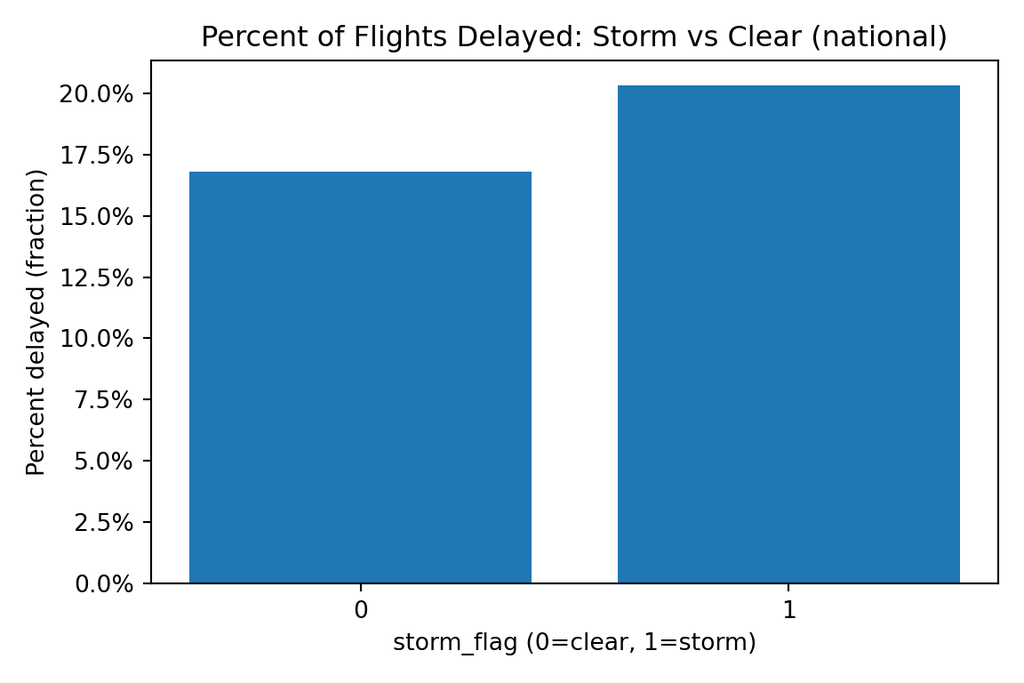

```python
# Plot 1A: Percent delayed (bar)
plt.figure(figsize=(6,4))
plt.bar(national_summary['storm_flag'].astype(str), national_summary['pct_delayed'])
plt.title('Percent of Flights Delayed: Storm vs Clear (national)')
plt.xlabel('storm_flag (0=clear, 1=storm)')
plt.ylabel('Percent delayed (fraction)')
plt.gca().yaxis.set_major_formatter(plt.FuncFormatter(lambda y, _: f"{y:.1%}"))
plt.tight_layout()
plt.show()
```

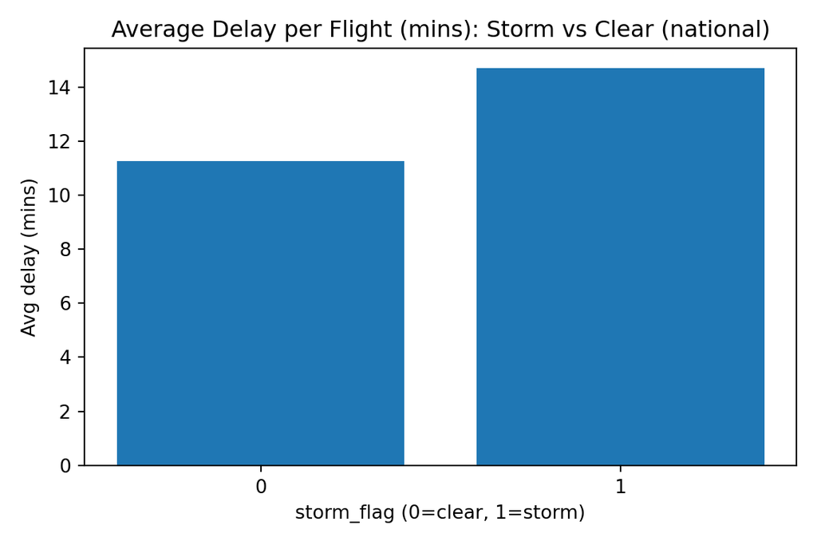

```python
# Plot 1B: Avg delay per flight (bar)
plt.figure(figsize=(6,4))
plt.bar(national_summary['storm_flag'].astype(str), national_summary['avg_delay_per_flight'])
plt.title('Average Delay per Flight (mins): Storm vs Clear (national)')
plt.xlabel('storm_flag (0=clear, 1=storm)')
plt.ylabel('Avg delay (mins)')
plt.tight_layout()
plt.show()
```

```python
# Plot 1C: n_state_months distribution (pie)
plt.figure(figsize=(5,5))
plt.pie(national_summary['n_state_months'], labels=national_summary['storm_flag'].astype(str), autopct='%1.1f%%')
```

[output not shown]

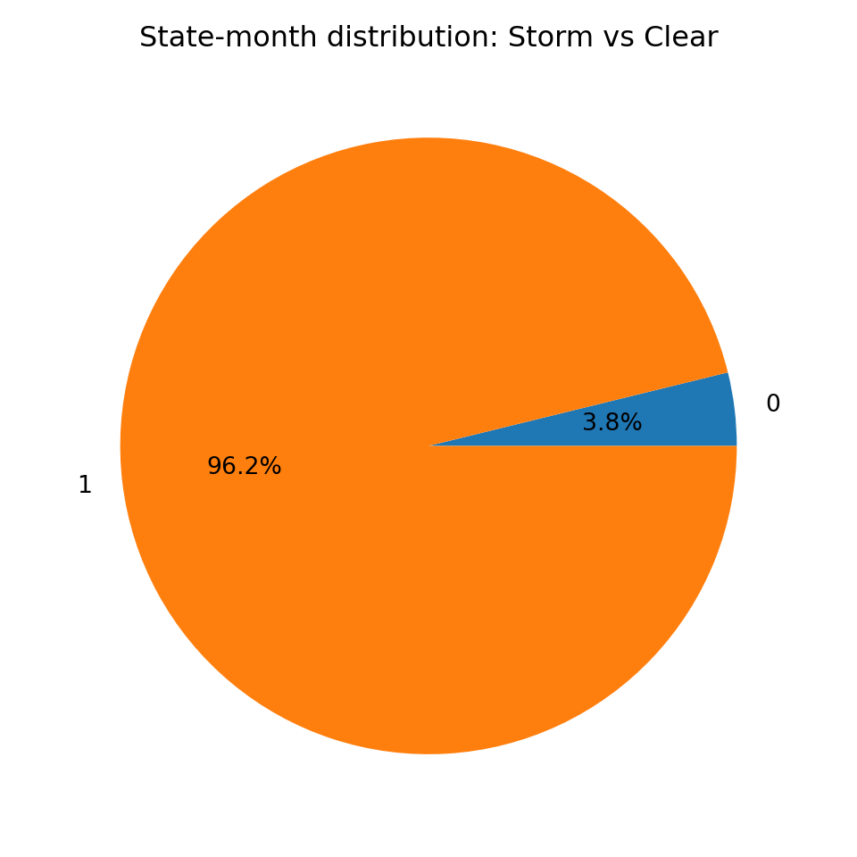

```python
plt.title('State-month distribution: Storm vs Clear')
plt.tight_layout()
plt.show()
```

#### State-level storm vs. clear comparison

```python
# 2. State-level storm impact
import numpy as np
import matplotlib.pyplot as plt

group = final_joined_table.copy()

state_agg = group.groupby('state', as_index=False).apply(
    lambda df: pd.Series({
        'flights_storm': df.loc[df['storm_flag']==1,'total_flights'].sum(),
        'delayed_storm': df.loc[df['storm_flag']==1,'total_delayed'].sum(),
        'flights_clear': df.loc[df['storm_flag']==0,'total_flights'].sum(),
        'delayed_clear': df.loc[df['storm_flag']==0,'total_delayed'].sum(),
    })
).reset_index()
# pct calculations safe-guarded
state_agg['pct_delayed_storm'] = np.where(state_agg['flights_storm']==0, np.nan, state_agg['delayed_storm'] / state_agg['flights_storm'])
state_agg['pct_delayed_clear'] = np.where(state_agg['flights_clear']==0, np.nan, state_agg['delayed_clear'] / state_agg['flights_clear'])

# prepare diff column
state_agg['diff'] = state_agg['pct_delayed_storm'] - state_agg['pct_delayed_clear']

# show
print(state_agg.head())
```

```
   index state  flights_storm  ...  pct_delayed_storm  pct_delayed_clear  diff
0      0    AK        42280.0  ...           0.199314                NaN   NaN
1      1    AL        41144.0  ...           0.199178                NaN   NaN
2      2    AR        31995.0  ...           0.205376                NaN   NaN
3      3    AZ       224915.0  ...           0.187729                NaN   NaN
4      4    CA       753692.0  ...           0.213737                NaN   NaN

[5 rows x 9 columns]
```

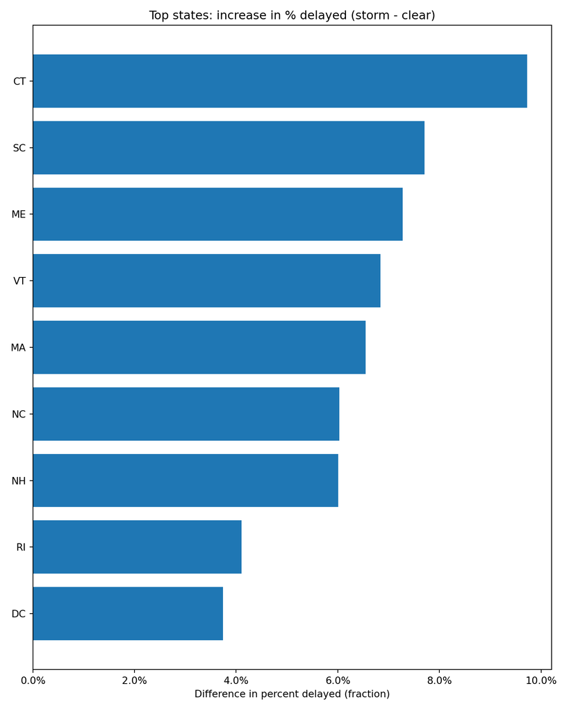

```python
# Plot: difference bar (sorted)
plot_df = state_agg.dropna(subset=['diff']).sort_values('diff', ascending=False).head(30)  # top 30 for readability
plt.figure(figsize=(8,10))
plt.barh(plot_df['state'].astype(str), plot_df['diff'])
plt.gca().invert_yaxis()
plt.title('Top states: increase in % delayed (storm - clear)')
plt.xlabel('Difference in percent delayed (fraction)')
plt.gca().xaxis.set_major_formatter(plt.FuncFormatter(lambda x, _: f"{x:.1%}"))
plt.tight_layout()
plt.show()
```

#### Top 10 storm months by delay severity

Identify the state–month combinations with storms that experienced the highest percentage of delayed flights. This ranking highlights where storm conditions aligned with the most severe operational disruptions.

```python
# 3. Top 10 storm months by percent delayed
import matplotlib.pyplot as plt

storm_months = final_joined_table[final_joined_table['storm_flag'] == 1].copy()
storm_months['pct_delayed'] = np.where(storm_months['total_flights']==0, np.nan, storm_months['total_delayed'] / storm_months['total_flights'])
top10 = storm_months.sort_values('pct_delayed', ascending=False).head(10).copy()

# label
top10['label'] = top10['yr'].astype(int).astype(str) + "-" + top10['mth'].astype(int).apply(lambda x: f"{x:02d}") + " (" + top10['state'].astype(str) + ")"

print(top10[['label','pct_delayed','total_flights','total_delayed']])
```

```
            label  pct_delayed  total_flights  total_delayed
317  2024-07 (LA)     0.343423         6409.0         2201.0
348  2024-07 (WV)     0.333333          474.0          158.0
301  2024-07 (AL)     0.331017         3598.0         1191.0
248  2024-05 (WV)     0.330935          417.0          138.0
302  2024-07 (AR)     0.330329         2885.0          953.0
326  2024-07 (NC)     0.327753        32436.0        10631.0
242  2024-05 (TX)     0.322623        71424.0        23043.0
316  2024-07 (KY)     0.322546         7385.0         2382.0
308  2024-07 (FL)     0.321535        51814.0        16660.0
306  2024-07 (CT)     0.320230         2086.0          668.0
```

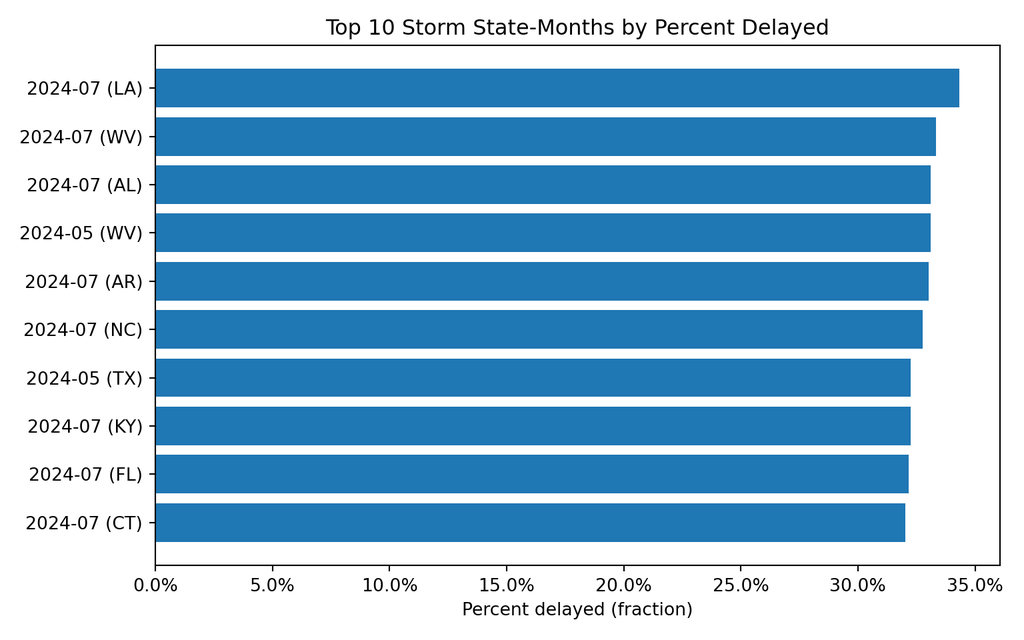

```python
# Plot horizontal bars
plt.figure(figsize=(8,5))
plt.barh(top10['label'], top10['pct_delayed'])
plt.gca().invert_yaxis()
plt.title('Top 10 Storm State-Months by Percent Delayed')
plt.xlabel('Percent delayed (fraction)')
plt.gca().xaxis.set_major_formatter(plt.FuncFormatter(lambda x, _: f"{x:.1%}"))
plt.tight_layout()
plt.show()
```

#### Monthly storm activity and delay patterns

Aggregate storm counts and flight delays across all states for each calendar month. This summary reveals seasonal trends in storm frequency and how delay rates vary throughout the year.

```python
# 4. Monthly pattern
import matplotlib.pyplot as plt

monthly = final_joined_table.groupby('mth', as_index=False).agg(
    storms = ('storm_events','sum'),
    flights = ('total_flights','sum'),
    delayed = ('total_delayed','sum')
)
monthly['pct_delayed'] = np.where(monthly['flights']==0, np.nan, monthly['delayed'] / monthly['flights'])

print(monthly)
```

```
    mth   storms   flights   delayed  pct_delayed
0     1   8340.0  576702.0  133089.0     0.230776
1     2   3493.0  547595.0   85004.0     0.155232
2     3   3662.0  622958.0  125929.0     0.202147
3     4   5450.0  614417.0  114858.0     0.186938
4     5  10596.0  643691.0  165197.0     0.256640
5     6   8157.0  645736.0  155794.0     0.241266
6     7   8632.0  670518.0  189953.0     0.283293
7     8   7359.0  655095.0  148524.0     0.226721
8     9   3201.0  617464.0   94522.0     0.153081
9    10   1638.0  651785.0   84160.0     0.129122
10   11   2535.0  609556.0   88455.0     0.145114
11   12   2956.0  625825.0  131042.0     0.209391
```

```python
# Plot: pct_delayed (line)
plt.figure(figsize=(8,4))
plt.plot(monthly['mth'], monthly['pct_delayed'], marker='o')
plt.title('Percent of Flights Delayed by Calendar Month')
plt.xlabel('Month')
plt.ylabel('Percent delayed (fraction)')
plt.gca().yaxis.set_major_formatter(plt.FuncFormatter(lambda y, _: f"{y:.1%}"))
plt.xticks(range(1,13))
```

[output not shown]

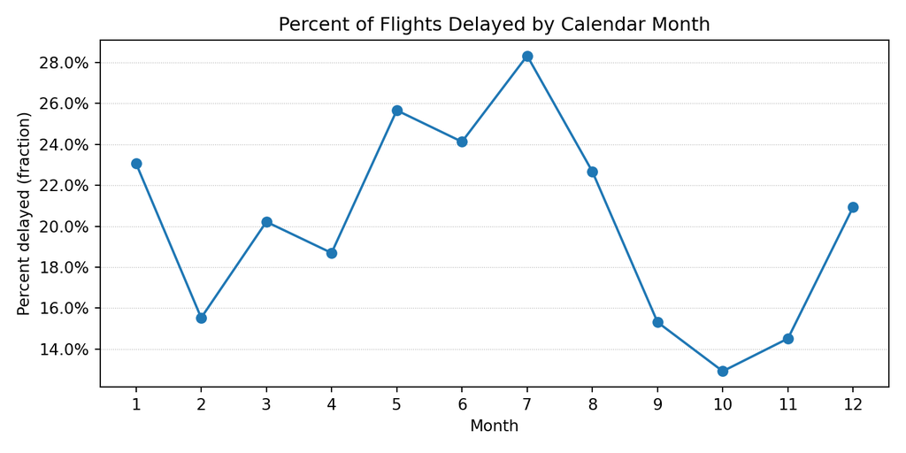

```python
plt.grid(axis='y', linestyle=':', linewidth=0.5)
plt.tight_layout()
plt.show()
```

```python
# Plot: storms per month (bar)
plt.figure(figsize=(8,4))
plt.bar(monthly['mth'], monthly['storms'])
plt.title('Total Storm Events by Calendar Month')
plt.xlabel('Month')
plt.ylabel('Storm events (count)')
plt.xticks(range(1,13))
```

[output not shown]

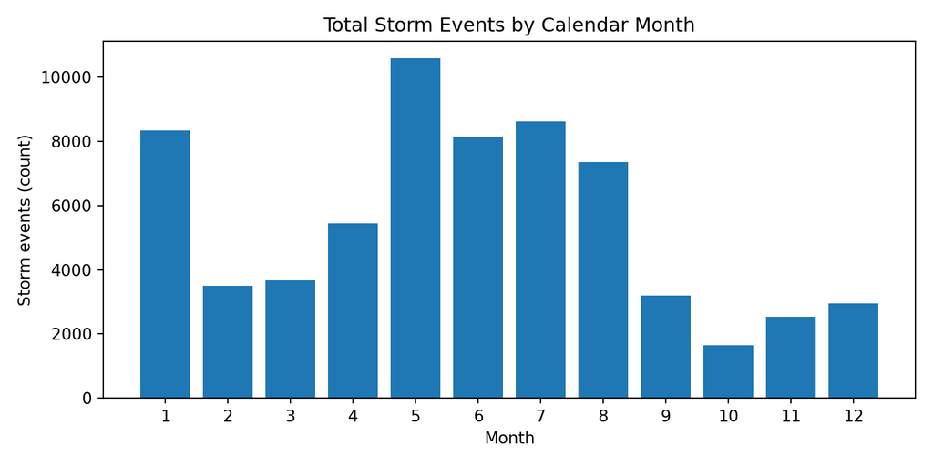

```python
plt.tight_layout()
plt.show()
```

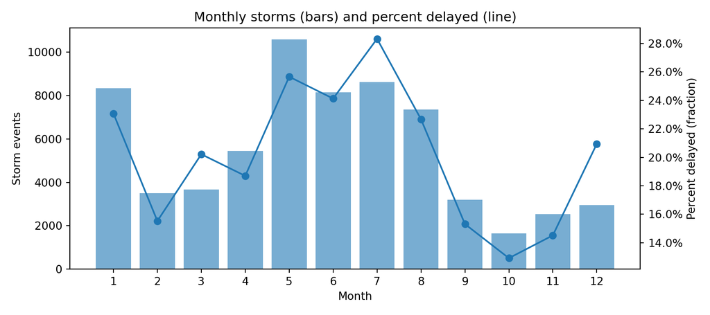

```python
# Optional: combined plot (bar+line)
fig, ax1 = plt.subplots(figsize=(9,4))
ax2 = ax1.twinx()
ax1.bar(monthly['mth'], monthly['storms'], alpha=0.6)
ax2.plot(monthly['mth'], monthly['pct_delayed'], marker='o')
ax1.set_xlabel('Month')
ax1.set_ylabel('Storm events')
ax2.set_ylabel('Percent delayed (fraction)')
ax2.yaxis.set_major_formatter(plt.FuncFormatter(lambda y, _: f"{y:.1%}"))
ax1.set_xticks(range(1,13))
plt.title('Monthly storms (bars) and percent delayed (line)')
fig.tight_layout()
plt.show()
```

#### State ranking by storm impact

```python
# 5. State ranking with difference (clean derivation)
import numpy as np
import matplotlib.pyplot as plt

agg = final_joined_table.groupby('state', as_index=False).apply(
    lambda df: pd.Series({
        'pct_delayed_storm': (df.loc[df['storm_flag']==1,'total_delayed'].sum() / df.loc[df['storm_flag']==1,'total_flights'].sum()) if df.loc[df['storm_flag']==1,'total_flights'].sum() != 0 else np.nan,
        'pct_delayed_clear': (df.loc[df['storm_flag']==0,'total_delayed'].sum() / df.loc[df['storm_flag']==0,'total_flights'].sum()) if df.loc[df['storm_flag']==0,'total_flights'].sum() != 0 else np.nan
    })
).reset_index()
agg = agg.dropna(subset=['pct_delayed_clear'])
agg['diff'] = agg['pct_delayed_storm'] - agg['pct_delayed_clear']
agg_sorted = agg.sort_values('diff', ascending=False)

print(agg_sorted.head(10))
```

```
    index state  pct_delayed_storm  pct_delayed_clear      diff
6       6    CT           0.245555           0.148322  0.097233
39     39    SC           0.203353           0.126273  0.077080
20     20    ME           0.201566           0.128766  0.072800
45     45    VT           0.204228           0.135822  0.068407
18     18    MA           0.233235           0.167741  0.065494
26     26    NC           0.215819           0.155524  0.060295
29     29    NH           0.214356           0.154237  0.060119
38     38    RI           0.230672           0.189641  0.041030
7       7    DC           0.218507           0.181067  0.037440
```

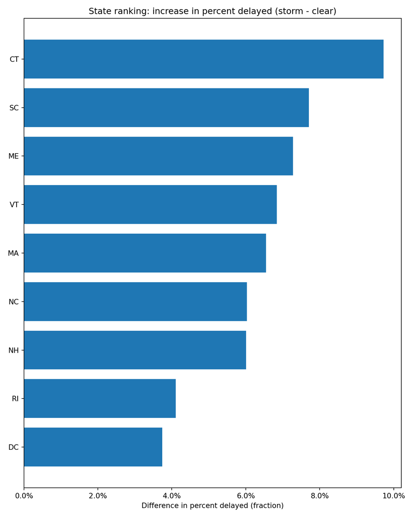

```python
# Plot top 25 states by diff
plot_df = agg_sorted.head(25)
plt.figure(figsize=(8,10))
plt.barh(plot_df['state'], plot_df['diff'])
plt.gca().invert_yaxis()
plt.title('State ranking: increase in percent delayed (storm - clear)')
plt.xlabel('Difference in percent delayed (fraction)')
plt.gca().xaxis.set_major_formatter(plt.FuncFormatter(lambda x, _: f"{x:.1%}"))
plt.tight_layout()
plt.show()
```

#### Delay causes in storm vs. clear conditions

Compare total delay minutes attributable to weather, carrier issues, and all causes across storm and non-storm months. This breakdown helps identify how much storms shift the balance of delay drivers at a national level.

```python
# 6. Compare delay cause totals in storm vs clear months
import matplotlib.pyplot as plt

cause_sums = final_joined_table.groupby('storm_flag', as_index=False).agg(
    weather_delay_mins = ('weather_delay_mins','sum'),
    carrier_delay_mins = ('carrier_delay_mins','sum'),
    total_delay_mins   = ('total_delay_mins','sum')
)

print(cause_sums)
```

```
   storm_flag  weather_delay_mins  carrier_delay_mins  total_delay_mins
0           0             62698.0            573295.0         1607447.0
1           1           6689855.0          36739504.0       107902722.0
```

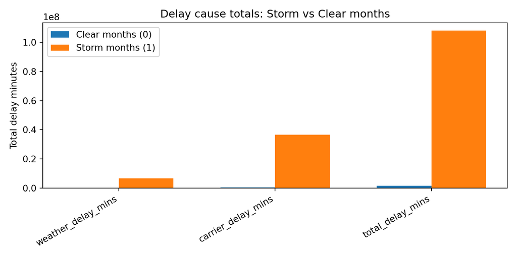

```python
# reshape for plotting
plot_df = cause_sums.melt(id_vars='storm_flag', value_vars=['weather_delay_mins','carrier_delay_mins','total_delay_mins'],
                          var_name='cause', value_name='minutes')

# grouped bar chart
labels = plot_df['cause'].unique()
x = np.arange(len(labels))
width = 0.35

# pivot to get values for storm_flag 0 and 1 aligned to labels
pivot = plot_df.pivot(index='cause', columns='storm_flag', values='minutes').reindex(labels)

fig, ax = plt.subplots(figsize=(8,4))
ax.bar(x - width/2, pivot[0].values, width, label='Clear months (0)')
ax.bar(x + width/2, pivot[1].values, width, label='Storm months (1)')
ax.set_xticks(x)
ax.set_xticklabels(labels, rotation=30, ha='right')
ax.set_ylabel('Total delay minutes')
ax.set_title('Delay cause totals: Storm vs Clear months')
ax.legend()
plt.tight_layout()
plt.show()
```